# Association of natural disaster and covid experiences with the number of depression symptoms, accounting for genetic risk of depression

#### Male

```r
# LRT to compare partial PO to PO models
lrtest(NDworse_male_PO, NDworse_male_PartPO_NDexpos)
```

```
## Likelihood ratio test
##
## Model 1: NUMSYMPALL_baseline_cat ~ PRS_stand_genetic + NDEXPOS_DEPRWAFTER +
##     AGE_baseline + PC1_genetic + PC2_genetic + PC3_genetic +
##     PC4_genetic + PC5_genetic + PC6_genetic + PC7_genetic + PC8_genetic +
##     PC9_genetic + PC10_genetic
## Model 2: NUMSYMPALL_baseline_cat ~ PRS_stand_genetic + NDEXPOS_DEPRWAFTER +
##     AGE_baseline + PC1_genetic + PC2_genetic + PC3_genetic +
##     PC4_genetic + PC5_genetic + PC6_genetic + PC7_genetic + PC8_genetic +
##     PC9_genetic + PC10_genetic
##    #Df  LogLik Df  Chisq Pr(>Chisq)
## 1 4261 -846.51
## 2 4260 -846.51 -1 0.0035      0.953
```

```r
lrtest(NDworse_male_PO, NDworse_male_PartPO_PRS)
```

```
## Likelihood ratio test
##
## Model 1: NUMSYMPALL_baseline_cat ~ PRS_stand_genetic + NDEXPOS_DEPRWAFTER +
##     AGE_baseline + PC1_genetic + PC2_genetic + PC3_genetic +
##     PC4_genetic + PC5_genetic + PC6_genetic + PC7_genetic + PC8_genetic +
##     PC9_genetic + PC10_genetic
## Model 2: NUMSYMPALL_baseline_cat ~ PRS_stand_genetic + NDEXPOS_DEPRWAFTER +
##     AGE_baseline + PC1_genetic + PC2_genetic + PC3_genetic +
##     PC4_genetic + PC5_genetic + PC6_genetic + PC7_genetic + PC8_genetic +
##     PC9_genetic + PC10_genetic
##    #Df  LogLik Df Chisq Pr(>Chisq)
## 1 4261 -846.51
## 2 4260 -846.16 -1 0.706     0.4008
```

```r
lrtest(NDworse_male_PO, NDworse_male_PartPO_NDexpos_PRS)
```

```
## Likelihood ratio test
##
## Model 1: NUMSYMPALL_baseline_cat ~ PRS_stand_genetic + NDEXPOS_DEPRWAFTER +
##     AGE_baseline + PC1_genetic + PC2_genetic + PC3_genetic +
##     PC4_genetic + PC5_genetic + PC6_genetic + PC7_genetic + PC8_genetic +
##     PC9_genetic + PC10_genetic
## Model 2: NUMSYMPALL_baseline_cat ~ PRS_stand_genetic + NDEXPOS_DEPRWAFTER +
##     AGE_baseline + PC1_genetic + PC2_genetic + PC3_genetic +
##     PC4_genetic + PC5_genetic + PC6_genetic + PC7_genetic + PC8_genetic +
##     PC9_genetic + PC10_genetic
##    #Df  LogLik Df  Chisq Pr(>Chisq)
## 1 4261 -846.51
## 2 4259 -846.15 -2 0.7222     0.6969
```

```r
### Test goodness of fit ###

# lipsitz test
lipsitz(NDworse_male_PartPO_NDexpos)
```

```
##
## Lipsitz Test:
##
##                       LR   df   pr(>chi)
## ordinal(lipsitz)  12.826    9     0.1706
##
## H0: No lack of fit dictated
```

```r
lipsitz(NDworse_male_PartPO_PRS)
```

```
##
## Lipsitz Test:
##
##                       LR   df   pr(>chi)
## ordinal(lipsitz)  6.8519    9     0.6525
##
## H0: No lack of fit dictated
```

```r
lipsitz(NDworse_male_PartPO_NDexpos_PRS)
```

```
##
## Lipsitz Test:
##
##                       LR   df   pr(>chi)
## ordinal(lipsitz)  6.4746    9     0.6916
##
## H0: No lack of fit dictated
```

```r
# pulkstenis-robinson test
# (requires the vector of categorical input variables as an argument)
pulkroben(NDworse_male_PartPO_NDexpos, test = c("chisq","deviance"), tables = FALSE)
```

```
##
## Pulkstenis-Robinson Chi-squared Test:
##
##                     chi-sq   df   pr(>chi)
## ordinal(pulkroben)  4.4965    4      0.343
##
## H0: No lack of fit dictated
##
## rho: 100%
```

```r
pulkroben(NDworse_male_PartPO_PRS, test = c("chisq","deviance"), tables = FALSE)
```

```
##
## Pulkstenis-Robinson Chi-squared Test:
##
##                     chi-sq   df   pr(>chi)
## ordinal(pulkroben)  4.6605    4     0.3239
##
## H0: No lack of fit dictated
##
## rho: 100%
```

```r
pulkroben(NDworse_male_PartPO_NDexpos_PRS, test = c("chisq","deviance"), tables = FALSE)
```

```
##
## Pulkstenis-Robinson Chi-squared Test:
##
##                     chi-sq   df   pr(>chi)
## ordinal(pulkroben)  4.6626    4     0.3237
##
## H0: No lack of fit dictated
##
## rho: 100%
```

```r
# Hosmer-Lemeshow test
hosmerlem(NDworse_male_PartPO_NDexpos)
```

```
##
## Hosmer-Lemeshow Test:
##
##                     Chi-sq  df  pr(>chi)
## ordinal(Hosmerlem)  23.736  17    0.1268
##
## H0: No lack of fit dictated
##
## rho: 93.33%
```

```r
hosmerlem(NDworse_male_PartPO_PRS)
```

```
##
## Hosmer-Lemeshow Test:
##
##                     Chi-sq  df  pr(>chi)
## ordinal(Hosmerlem)   16.72  17    0.4735
##
## H0: No lack of fit dictated
##
## rho: 96.67%
```

```r
hosmerlem(NDworse_male_PartPO_PRS)
```

```
##
## Hosmer-Lemeshow Test:
##
##                     Chi-sq  df  pr(>chi)
## ordinal(Hosmerlem)   16.72  17    0.4735
##
## H0: No lack of fit dictated
##
## rho: 96.67%
```

- Relaxing PO assumption for ND exposure and/or PRS does not significantly improve model
- So best to use PO model

## Model Investigation

### Proportional Odds

#### Both Sexes

##### Results

```r
summary(NDworse_PO)
```

```
##
## Call:
## VGAM::vglm(formula = NUMSYMPALL_baseline_cat ~ PRS_stand_genetic +
##     NDEXPOS_DEPRWAFTER + AGE_baseline + SEX_genetic + PC1_genetic +
##     PC2_genetic + PC3_genetic + PC4_genetic + PC5_genetic + PC6_genetic +
##     PC7_genetic + PC8_genetic + PC9_genetic + PC10_genetic, family = VGAM::cumulative(logitlink,
##     parallel = T, reverse = T), data = df_ND_covid)
##
## Coefficients:
##                         Estimate Std. Error z value Pr(>|z|)
## (Intercept):1           7.753442   1.126135   6.885 5.78e-12 ***
## (Intercept):2           4.582252   1.114038   4.113 3.90e-05 ***
## PRS_stand_genetic       0.152647   0.038605   3.954 7.68e-05 ***
## NDEXPOS_DEPRWAFTERYes   0.338545   0.084842   3.990 6.60e-05 ***
## AGE_baseline           -0.033156   0.002643 -12.544  < 2e-16 ***
## SEX_geneticFemale       0.398164   0.082886   4.804 1.56e-06 ***
## PC1_genetic            42.474969  76.368915   0.556   0.5781
## PC2_genetic           -56.550351  38.076050  -1.485   0.1375
## PC3_genetic           -12.582034  25.086829  -0.502   0.6160
## PC4_genetic             9.530281  25.658846   0.371   0.7103
## PC5_genetic             9.612089  13.602520   0.707   0.4798
## PC6_genetic             3.273408   6.232664   0.525   0.5994
## PC7_genetic            11.118208  12.730910   0.873   0.3825
## PC8_genetic           -22.756456  11.106937  -2.049   0.0405 *
## PC9_genetic           -12.090241   9.328986  -1.296   0.1950
## PC10_genetic          -11.124318   9.188783  -1.211   0.2260
## ---
## Signif. codes:  0 '***' 0.001 '**' 0.01 '*' 0.05 '.' 0.1 ' ' 1
##
## Names of linear predictors: logitlink(P[Y>=2]), logitlink(P[Y>=3])
##
## Residual deviance: 5176.393 on 17346 degrees of freedom
##
## Log-likelihood: -2588.196 on 17346 degrees of freedom
##
## Number of Fisher scoring iterations: 5
##
##
## Exponentiated coefficients:
##     PRS_stand_genetic NDEXPOS_DEPRWAFTERYes          AGE_baseline
##          1.164914e+00          1.402905e+00          9.673877e-01
##     SEX_geneticFemale           PC1_genetic           PC2_genetic
##          1.489088e+00          2.796693e+18          2.757368e-25
##           PC3_genetic           PC4_genetic           PC5_genetic
##          3.433143e-06          1.377046e+04          1.494436e+04
##           PC6_genetic           PC7_genetic           PC8_genetic
##          2.640117e+01          6.738704e+04          1.309173e-10
##           PC9_genetic          PC10_genetic
##          5.614037e-06          1.474925e-05
```

```r
# Create nice summary of results, including back transformation to give OR and calculating 95% CI
CI <- as.data.frame(confint(NDworse_PO)) %>%
  rownames_to_column() %>%
  rename('lower_95_CI_of_beta' = "2.5 %",
         'upper_95_CI_of_beta' = "97.5 %") %>%
  mutate(lower_95_CI_of_OR = exp(lower_95_CI_of_beta),
         upper_95_CI_of_OR = exp(upper_95_CI_of_beta))

beta <- as.data.frame(coef(NDworse_PO)) %>%
  rownames_to_column() %>%
  rename("beta" = "coef(NDworse_PO)") %>%
  mutate(OR = exp(beta))

results <- beta %>%
  full_join(CI) %>%
  relocate(rowname, beta, lower_95_CI_of_beta, upper_95_CI_of_beta, OR, lower_95_CI_of_OR, upper_95_CI_of_OR)

results %>% kable()
```

| rowname | beta | lower_95_CI_of_beta | upper_95_CI_of_beta | OR | lower_95_CI_of_OR | upper_95_CI_of_OR |
| --- | --- | --- | --- | --- | --- | --- |
| (Intercept):1 | 7.7534418 | 5.5462581 | 9.9606255 | 2.329577e+03 | 256.2768012 | 2.117604e+04 |
| (Intercept):2 | 4.5822524 | 2.3987781 | 6.7657266 | 9.773428e+01 | 11.0097157 | 8.675964e+02 |
| PRS_stand_genetic | 0.1526470 | 0.0769826 | 0.2283115 | 1.164914e+00 | 1.0800233 | 1.256477e+00 |
| NDEXPOS_DEPRWAFTERYes | 0.3385452 | 0.1722579 | 0.5048325 | 1.402905e+00 | 1.1879842 | 1.656708e+00 |
| AGE_baseline | -0.0331560 | -0.0383365 | -0.0279754 | 9.673877e-01 | 0.9623891 | 9.724122e-01 |
| SEX_geneticFemale | 0.3981638 | 0.2357105 | 0.5606172 | 1.489088e+00 | 1.2658078 | 1.751753e+00 |
| PC1_genetic | 42.4749692 | -107.2053541 | 192.1552925 | 2.796693e+18 | 0.0000000 | 2.831282e+83 |
| PC2_genetic | -56.5503507 | -131.1780381 | 18.0773368 | 0.000000e+00 | 0.0000000 | 7.093942e+07 |
| PC3_genetic | -12.5820344 | -61.7513165 | 36.5872476 | 3.400000e-06 | 0.0000000 | 7.756035e+15 |
| PC4_genetic | 9.5302813 | -40.7601332 | 59.8206958 | 1.377046e+04 | 0.0000000 | 9.545487e+25 |
| PC5_genetic | 9.6120894 | -17.0483594 | 36.2725382 | 1.494436e+04 | 0.0000000 | 5.661913e+15 |
| PC6_genetic | 3.2734085 | -8.9423891 | 15.4892060 | 2.640117e+01 | 0.0001307 | 5.331835e+06 |
| PC7_genetic | 11.1182081 | -13.8339174 | 36.0703335 | 6.738704e+04 | 0.0000010 | 4.625373e+15 |
| PC8_genetic | -22.7564556 | -44.5256518 | -0.9872595 | 0.000000e+00 | 0.0000000 | 3.725964e-01 |
| PC9_genetic | -12.0902406 | -30.3747167 | 6.1942356 | 5.600000e-06 | 0.0000000 | 4.899168e+02 |
| PC10_genetic | -11.1243183 | -29.1340011 | 6.8853646 | 1.470000e-05 | 0.0000000 | 9.778581e+02 |

##### Plots

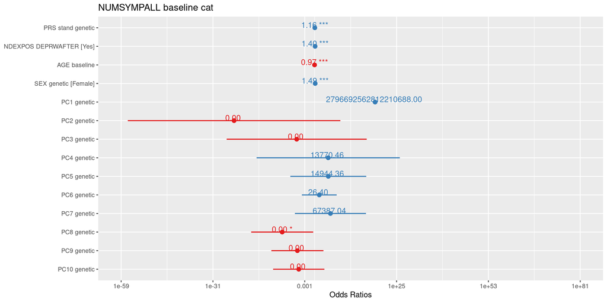

```r
plot_model(NDworse_PO,
           type = 'est',
           show.values = T)
```

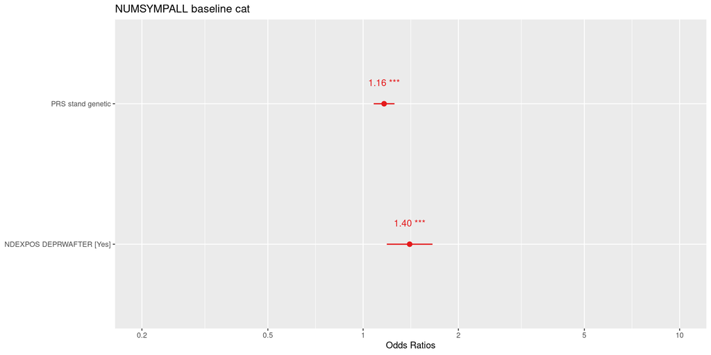

```r
plot_model(NDworse_PO,
           type = 'est',
           show.values = T,
           terms = c('PRS_stand_genetic', 'NDEXPOS_DEPRWAFTERYes'))
```

#### Female

##### Results

```r
summary(NDworse_female_PO)
```

```
##
## Call:
## VGAM::vglm(formula = NUMSYMPALL_baseline_cat ~ PRS_stand_genetic +
##     NDEXPOS_DEPRWAFTER + AGE_baseline + PC1_genetic + PC2_genetic +
##     PC3_genetic + PC4_genetic + PC5_genetic + PC6_genetic + PC7_genetic +
##     PC8_genetic + PC9_genetic + PC10_genetic, family = VGAM::cumulative(logitlink,
##     parallel = T, reverse = T), data = df_ND_covid[df_ND_covid$SEX_genetic ==
##     "Female", ])
##
## Coefficients:
##                         Estimate Std. Error z value Pr(>|z|)
## (Intercept):1           9.026941   1.371335   6.583 4.62e-11 ***
## (Intercept):2           5.376746   1.345354   3.997 6.43e-05 ***
## PRS_stand_genetic       0.101537   0.047612   2.133   0.0330 *
## NDEXPOS_DEPRWAFTERYes   0.271777   0.104936   2.590   0.0096 **
## AGE_baseline           -0.033872   0.003204 -10.571  < 2e-16 ***
## PC1_genetic           -72.967935  95.736588  -0.762   0.4460
## PC2_genetic           -19.259270  42.911439  -0.449   0.6536
## PC3_genetic           -42.177944  30.307450  -1.392   0.1640
## PC4_genetic            36.738957  31.486252   1.167   0.2433
## PC5_genetic             4.280013  16.763230   0.255   0.7985
## PC6_genetic             5.334963   7.576801   0.704   0.4814
## PC7_genetic            19.730578  15.482662   1.274   0.2025
## PC8_genetic           -30.854900  13.780204  -2.239   0.0252 *
## PC9_genetic           -18.602857  11.516603  -1.615   0.1062
## PC10_genetic           -9.408530  11.364447  -0.828   0.4077
## ---
## Signif. codes:  0 '***' 0.001 '**' 0.01 '*' 0.05 '.' 0.1 ' ' 1
##
## Names of linear predictors: logitlink(P[Y>=2]), logitlink(P[Y>=3])
##
## Residual deviance: 3456.225 on 13071 degrees of freedom
##
## Log-likelihood: -1728.112 on 13071 degrees of freedom
##
## Number of Fisher scoring iterations: 4
##
##
## Exponentiated coefficients:
##     PRS_stand_genetic NDEXPOS_DEPRWAFTERYes          AGE_baseline
##          1.106871e+00          1.312294e+00          9.666954e-01
##           PC1_genetic           PC2_genetic           PC3_genetic
##          2.043754e-32          4.323199e-09          4.812286e-19
##           PC4_genetic           PC5_genetic           PC6_genetic
##          9.026645e+15          7.224140e+01          2.074650e+02
##           PC7_genetic           PC8_genetic           PC9_genetic
##          3.705791e+08          3.980038e-14          8.334546e-09
##          PC10_genetic
##          8.202143e-05
```

```r
# Create nice summary of results, including back transformation to give OR and calculating 95% CI
CI <- as.data.frame(confint(NDworse_female_PO)) %>%
  rownames_to_column() %>%
  rename('lower_95_CI_of_beta' = "2.5 %",
         'upper_95_CI_of_beta' = "97.5 %") %>%
  mutate(lower_95_CI_of_OR = exp(lower_95_CI_of_beta),
         upper_95_CI_of_OR = exp(upper_95_CI_of_beta))

beta <- as.data.frame(coef(NDworse_female_PO)) %>%
  rownames_to_column() %>%
  rename("beta" = "coef(NDworse_female_PO)") %>%
  mutate(OR = exp(beta))

results <- beta %>%
  full_join(CI) %>%
  relocate(rowname, beta, lower_95_CI_of_beta, upper_95_CI_of_beta, OR, lower_95_CI_of_OR, upper_95_CI_of_OR)

results %>% kable()
```

| rowname | beta | lower_95_CI_of_beta | upper_95_CI_of_beta | OR | lower_95_CI_of_OR | upper_95_CI_of_OR |
| --- | --- | --- | --- | --- | --- | --- |
| (Intercept):1 | 9.0269411 | 6.3391732 | 11.7147090 | 8.324357e+03 | 566.3278968 | 1.223583e+05 |
| (Intercept):2 | 5.3767459 | 2.7398996 | 8.0135921 | 2.163172e+02 | 15.4854305 | 3.021752e+03 |
| PRS_stand_genetic | 0.1015367 | 0.0082186 | 0.1948549 | 1.106871e+00 | 1.0082524 | 1.215135e+00 |
| NDEXPOS_DEPRWAFTERYes | 0.2717768 | 0.0661067 | 0.4774470 | 1.312294e+00 | 1.0683407 | 1.611954e+00 |
| AGE_baseline | -0.0338718 | -0.0401519 | -0.0275916 | 9.666954e-01 | 0.9606435 | 9.727855e-01 |
| PC1_genetic | -72.9679347 | -260.6081988 | 114.6723294 | 0.000000e+00 | 0.0000000 | 6.332277e+49 |
| PC2_genetic | -19.2592702 | -103.3641458 | 64.8456055 | 0.000000e+00 | 0.0000000 | 1.452408e+28 |
| PC3_genetic | -42.1779445 | -101.5794544 | 17.2235655 | 0.000000e+00 | 0.0000000 | 3.020643e+07 |
| PC4_genetic | 36.7389571 | -24.9729635 | 98.4508778 | 9.026645e+15 | 0.0000000 | 5.710484e+42 |
| PC5_genetic | 4.2800133 | -28.5753134 | 37.1353399 | 7.224140e+01 | 0.0000000 | 1.341755e+16 |
| PC6_genetic | 5.3349628 | -9.5152942 | 20.1852197 | 2.074650e+02 | 0.0000737 | 5.838880e+08 |
| PC7_genetic | 19.7305776 | -10.6148833 | 50.0760384 | 3.705791e+08 | 0.0000245 | 5.594318e+21 |
| PC8_genetic | -30.8549000 | -57.8636033 | -3.8461968 | 0.000000e+00 | 0.0000000 | 2.136080e-02 |
| PC9_genetic | -18.6028568 | -41.1749830 | 3.9692693 | 0.000000e+00 | 0.0000000 | 5.294583e+01 |
| PC10_genetic | -9.4085300 | -31.6824377 | 12.8653776 | 8.200000e-05 | 0.0000000 | 3.866896e+05 |

##### Plots

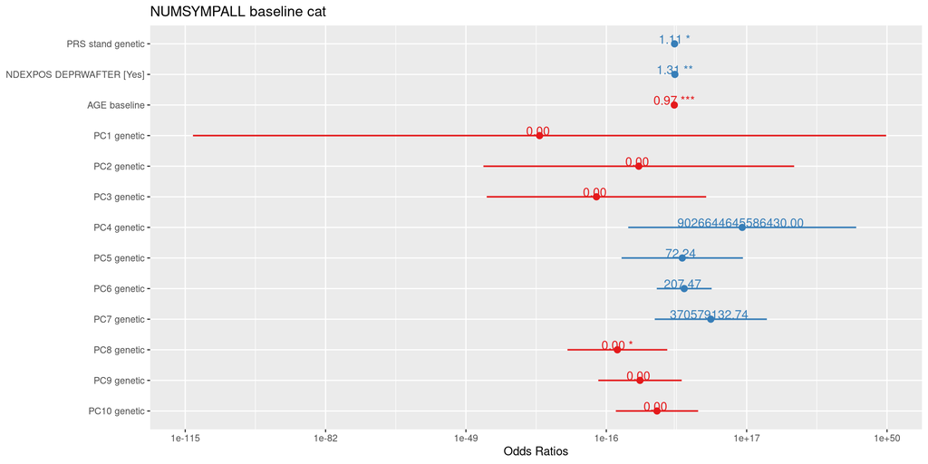

```r
plot_model(NDworse_female_PO,
           type = 'est',
           show.values = T)
```

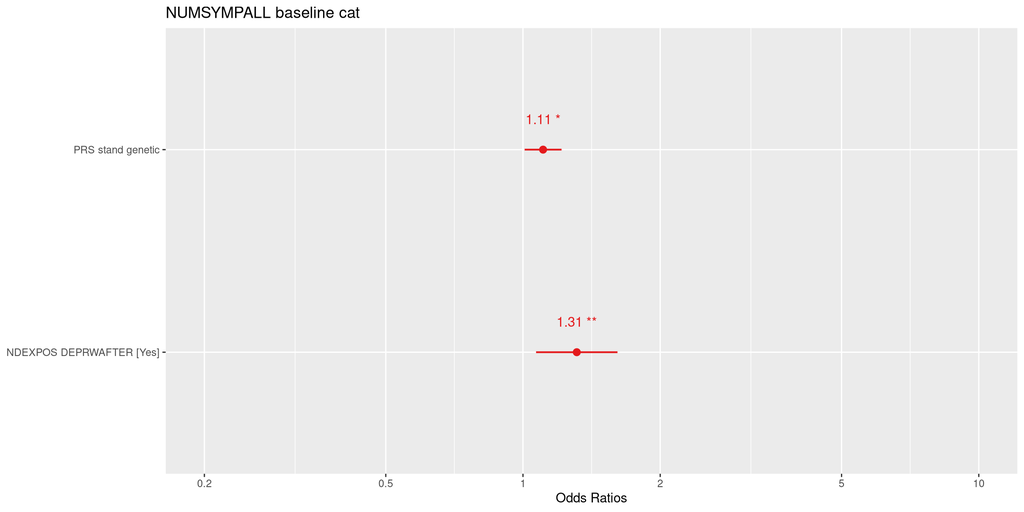

```r
plot_model(NDworse_female_PO,
           type = 'est',
           show.values = T,
           terms = c('PRS_stand_genetic', 'NDEXPOS_DEPRWAFTERYes'))
```

#### Male

##### Results

```r
summary(NDworse_male_PO)
```

```
##
## Call:
## VGAM::vglm(formula = NUMSYMPALL_baseline_cat ~ PRS_stand_genetic +
##     NDEXPOS_DEPRWAFTER + AGE_baseline + PC1_genetic + PC2_genetic +
##     PC3_genetic + PC4_genetic + PC5_genetic + PC6_genetic + PC7_genetic +
##     PC8_genetic + PC9_genetic + PC10_genetic, family = VGAM::cumulative(logitlink,
##     parallel = T, reverse = T), data = df_ND_covid[df_ND_covid$SEX_genetic ==
##     "Male", ])
##
## Coefficients:
##                         Estimate Std. Error z value Pr(>|z|)
## (Intercept):1          7.596e+00  2.120e+00   3.583 0.000339 ***
## (Intercept):2          4.912e+00  2.109e+00   2.329 0.019865 *
## PRS_stand_genetic      2.419e-01  6.657e-02   3.634 0.000279 ***
## NDEXPOS_DEPRWAFTERYes  4.498e-01  1.445e-01   3.113 0.001850 **
## AGE_baseline          -3.195e-02  4.703e-03  -6.792  1.1e-11 ***
## PC1_genetic            2.648e+02  1.319e+02   2.008 0.044687 *
## PC2_genetic           -1.677e+02  7.977e+01  -2.102 0.035538 *
## PC3_genetic            4.264e+01  4.832e+01   0.882 0.377593
## PC4_genetic           -4.134e+01  4.689e+01  -0.882 0.378001
## PC5_genetic            2.185e+01  2.357e+01   0.927 0.353829
## PC6_genetic            7.172e-01  1.110e+01   0.065 0.948462
## PC7_genetic           -4.495e+00  2.249e+01  -0.200 0.841562
## PC8_genetic           -8.083e+00  1.884e+01  -0.429 0.667971
## PC9_genetic           -3.712e-01  1.611e+01  -0.023 0.981613
## PC10_genetic          -1.484e+01  1.572e+01  -0.943 0.345438
## ---
## Signif. codes:  0 '***' 0.001 '**' 0.01 '*' 0.05 '.' 0.1 ' ' 1
##
## Names of linear predictors: logitlink(P[Y>=2]), logitlink(P[Y>=3])
##
## Residual deviance: 1693.024 on 4261 degrees of freedom
##
## Log-likelihood: -846.512 on 4261 degrees of freedom
##
## Number of Fisher scoring iterations: 5
##
##
## Exponentiated coefficients:
##     PRS_stand_genetic NDEXPOS_DEPRWAFTERYes          AGE_baseline
##          1.273663e+00          1.567936e+00          9.685586e-01
##           PC1_genetic           PC2_genetic           PC3_genetic
##         1.038039e+115          1.485095e-73          3.286744e+18
##           PC4_genetic           PC5_genetic           PC6_genetic
##          1.111714e-18          3.094346e+09          2.048664e+00
##           PC7_genetic           PC8_genetic           PC9_genetic
##          1.116813e-02          3.088187e-04          6.899181e-01
##          PC10_genetic
##          3.606299e-07
```

```r
# Create nice summary of results, including back transformation to give OR and calculating 95% CI
CI <- as.data.frame(confint(NDworse_male_PO)) %>%
  rownames_to_column() %>%
  rename('lower_95_CI_of_beta' = "2.5 %",
         'upper_95_CI_of_beta' = "97.5 %") %>%
  mutate(lower_95_CI_of_OR = exp(lower_95_CI_of_beta),
         upper_95_CI_of_OR = exp(upper_95_CI_of_beta))

beta <- as.data.frame(coef(NDworse_male_PO)) %>%
  rownames_to_column() %>%
  rename("beta" = "coef(NDworse_male_PO)") %>%
  mutate(OR = exp(beta))

results <- beta %>%
  full_join(CI) %>%
  relocate(rowname, beta, lower_95_CI_of_beta, upper_95_CI_of_beta, OR, lower_95_CI_of_OR, upper_95_CI_of_OR)

results %>% kable()
```

| rowname | beta | lower_95_CI_of_beta | upper_95_CI_of_beta | OR | lower_95_CI_of_OR | upper_95_CI_of_OR |
| --- | --- | --- | --- | --- | --- | --- |
| (Intercept):1 | 7.5957675 | 3.4412448 | 11.7502903 | 1.989756e+03 | 31.2258035 | 1.267904e+05 |
| (Intercept):2 | 4.9116397 | 0.7780647 | 9.0452148 | 1.358620e+02 | 2.1772546 | 8.477872e+03 |
| PRS_stand_genetic | 0.2418972 | 0.1114221 | 0.3723724 | 1.273663e+00 | 1.1178667 | 1.451173e+00 |
| NDEXPOS_DEPRWAFTERYes | 0.4497599 | 0.1666212 | 0.7328986 | 1.567936e+00 | 1.1813067 | 2.081104e+00 |
| AGE_baseline | -0.0319463 | -0.0411645 | -0.0227281 | 9.685586e-01 | 0.9596712 | 9.775283e-01 |
| PC1_genetic | 264.8346189 | 6.2822664 | 523.3869713 | 1.038039e+115 | 534.9998096 | 2.014065e+227 |
| PC2_genetic | -167.6932333 | -324.0418748 | -11.3445919 | 0.000000e+00 | 0.0000000 | 1.180000e-05 |
| PC3_genetic | 42.6364292 | -52.0729278 | 137.3457862 | 3.286744e+18 | 0.0000000 | 4.451610e+59 |
| PC4_genetic | -41.3406284 | -133.2502423 | 50.5689855 | 0.000000e+00 | 0.0000000 | 9.158648e+21 |
| PC5_genetic | 21.8528424 | -24.3414425 | 68.0471272 | 3.094346e+09 | 0.0000000 | 3.568551e+29 |
| PC6_genetic | 0.7171878 | -21.0293820 | 22.4637577 | 2.048664e+00 | 0.0000000 | 5.700146e+09 |
| PC7_genetic | -4.4946907 | -48.5648576 | 39.5754762 | 1.116810e-02 | 0.0000000 | 1.539611e+17 |
| PC8_genetic | -8.0827563 | -45.0159779 | 28.8504653 | 3.088000e-04 | 0.0000000 | 3.385306e+12 |
| PC9_genetic | -0.3711824 | -31.9383179 | 31.1959531 | 6.899181e-01 | 0.0000000 | 3.533705e+13 |
| PC10_genetic | -14.8354136 | -45.6543229 | 15.9834957 | 4.000000e-07 | 0.0000000 | 8.740655e+06 |

##### Plots

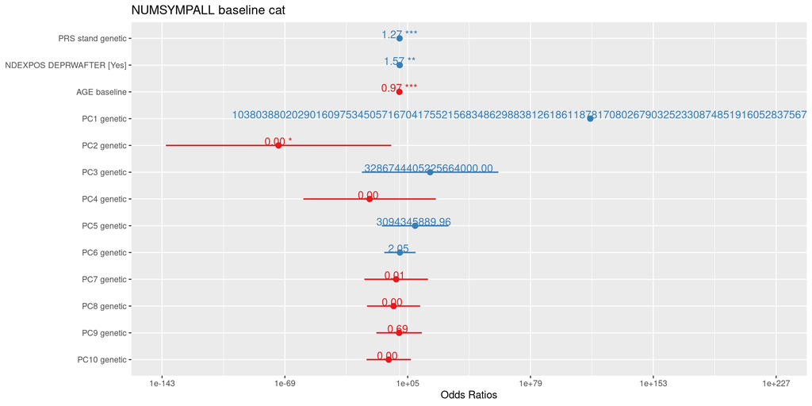

```r
plot_model(NDworse_male_PO,
           type = 'est',
           show.values = T)
```

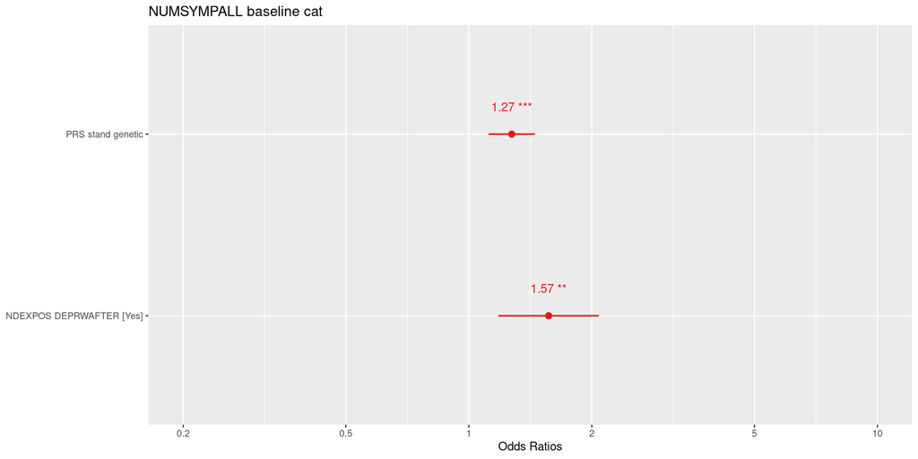

```r
plot_model(NDworse_male_PO,
           type = 'est',
           show.values = T,
           terms = c('PRS_stand_genetic', 'NDEXPOS_DEPRWAFTERYes'))
```

#### Female vs Male

- Conduct a Z test for the difference between the coefficients of females and males

```r
female_beta <- coef(summary(NDworse_female_PO))["NDEXPOS_DEPRWAFTERYes", "Estimate"]
female_SE <- coef(summary(NDworse_female_PO))["NDEXPOS_DEPRWAFTERYes", "Std. Error"]
male_beta <- coef(summary(NDworse_male_PO))["NDEXPOS_DEPRWAFTERYes", "Estimate"]
male_SE <- coef(summary(NDworse_male_PO))["NDEXPOS_DEPRWAFTERYes", "Std. Error"]

Z <- (female_beta - male_beta) / sqrt((female_SE)^2 + (male_SE)^2)
p <- 2 * pnorm(abs(Z), mean = 0, sd = 1, lower.tail = FALSE)

message <- sprintf("Association of ND experience on no. symptoms during worst depressive episode in females compared to males, Z = %.6f, p = %.6f", Z, p)
print(message)
```

```
## [1] "Association of ND experience on no. symptoms during worst depressive episode in females compared to males, Z = -0.996818, p = 0.318853"
```

# Natural Disaster (first depression)

- Effect of Natural disaster experience on no. depressive symptoms if first depressive episode occurred after the Natural disaster
- ND questions from baseline survey
- First depression symptoms from follow-up survey

## Explore

### Sample size

```r
df_ND_covid %>%
  drop_na(NUMSYMPALL_followup, SEX_genetic, AGE_baseline, matches("^PC.*_genetic$"), NDEXPOS_DEPRFAFTER, PRS_stand_genetic) %>%
  count(NDEXPOS_DEPRFAFTER) %>%
  kable(caption = "No. participants exposed to a natural disaster \n (Yes = ND happened to me, witnessed it, learned about it or part of my job - only if **first** depression occurred after ND experience \nNo = never experienced ND)")
```

No. participants exposed to a natural disaster (Yes = ND happened to me, witnessed it, learned about it or part of my job - only if **first** depression occurred after ND experience No = never experienced ND)

| NDEXPOS_DEPRFAFTER | n |
| --- | --- |
| No | 3147 |
| Yes | 1150 |

```r
df_ND_covid %>%
  drop_na(NUMSYMPALL_followup, SEX_genetic, AGE_baseline, matches("^PC.*_genetic$"), NDEXPOS_DEPRFAFTER, PRS_stand_genetic) %>%
  filter(SEX_genetic == "Female") %>%
  count(NDEXPOS_DEPRFAFTER) %>%
  kable(caption = "No. female participants exposed to a natural disaster \n (Yes = ND happened to me, witnessed it, learned about it or part of my job - only if **first** depression occurred after ND experience \nNo = never experienced ND)")
```

No. female participants exposed to a natural disaster (Yes = ND happened to me, witnessed it, learned about it or part of my job - only if **first** depression occurred after ND experience No = never experienced ND)

| NDEXPOS_DEPRFAFTER | n |
| --- | --- |
| No | 2408 |
| Yes | 836 |

```r
df_ND_covid %>%
  drop_na(NUMSYMPALL_followup, SEX_genetic, AGE_baseline, matches("^PC.*_genetic$"), NDEXPOS_DEPRFAFTER, PRS_stand_genetic) %>%
  filter(SEX_genetic == "Male") %>%
  count(NDEXPOS_DEPRFAFTER) %>%
  kable(caption = "No. male participants exposed to a natural disaster \n (Yes = ND happened to me, witnessed it, learned about it or part of my job - only if **first** depression occurred after ND experience \nNo = never experienced ND)")
```

No. male participants exposed to a natural disaster (Yes = ND happened to me, witnessed it, learned about it or part of my job - only if **first** depression occurred after ND experience No = never experienced ND)

| NDEXPOS_DEPRFAFTER | n |
| --- | --- |
| No | 739 |
| Yes | 314 |

### Distribution

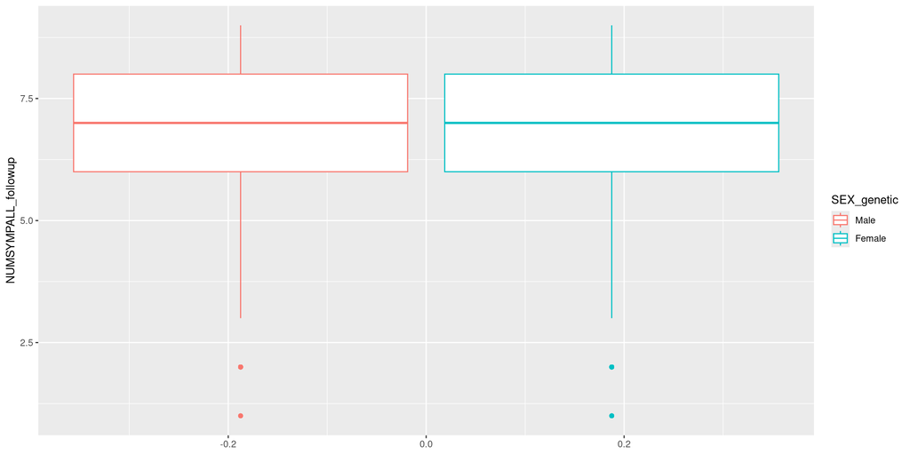

```r
ggplot(df_ND_covid[!is.na(df_ND_covid$NUMSYMPALL_followup) & !is.na(df_ND_covid$SEX_genetic),],
             aes(y = NUMSYMPALL_followup, colour = SEX_genetic)) +
  geom_boxplot()
```

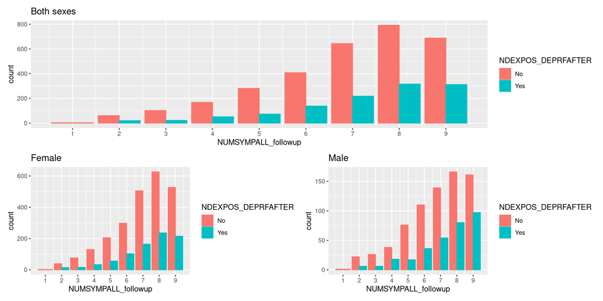

```r
p1 <- ggplot(df_ND_covid[!is.na(df_ND_covid$NUMSYMPALL_followup) &
                           !is.na(df_ND_covid$SEX_genetic) &
                           !is.na(df_ND_covid$NDEXPOS_DEPRFAFTER), ],
             aes (x = NUMSYMPALL_followup, colour = NDEXPOS_DEPRFAFTER, fill = NDEXPOS_DEPRFAFTER)) +
  geom_bar(position = "dodge") +
  scale_x_continuous(breaks = c(1,2,3,4,5,6,7,8,9)) +
  ggtitle("Both sexes")

p2 <- ggplot(df_ND_covid[!is.na(df_ND_covid$NUMSYMPALL_followup) &
                           !is.na(df_ND_covid$SEX_genetic) &
                           (df_ND_covid$SEX_genetic == "Female") &
                           !is.na(df_ND_covid$NDEXPOS_DEPRFAFTER), ],
             aes (x = NUMSYMPALL_followup, colour = NDEXPOS_DEPRFAFTER, fill = NDEXPOS_DEPRFAFTER)) +
  geom_bar(position = "dodge") +
  scale_x_continuous(breaks = c(1,2,3,4,5,6,7,8,9)) +
  ggtitle("Female")

p3 <- ggplot(df_ND_covid[!is.na(df_ND_covid$NUMSYMPALL_followup) &
                           !is.na(df_ND_covid$SEX_genetic) &
                           (df_ND_covid$SEX_genetic == "Male") &
                           !is.na(df_ND_covid$NDEXPOS_DEPRFAFTER), ],
             aes (x = NUMSYMPALL_followup, colour = NDEXPOS_DEPRFAFTER, fill = NDEXPOS_DEPRFAFTER)) +
  geom_bar(position = "dodge") +
  scale_x_continuous(breaks = c(1,2,3,4,5,6,7,8,9)) +
  ggtitle("Male")

p1 / (p2 | p3)
```

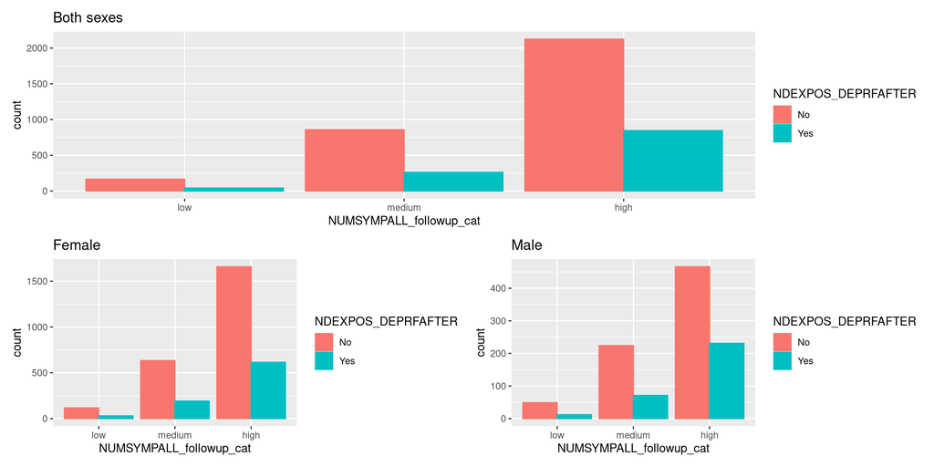

```r
p1 <- ggplot(df_ND_covid[!is.na(df_ND_covid$NUMSYMPALL_followup_cat) &
                           !is.na(df_ND_covid$SEX_genetic) &
                           !is.na(df_ND_covid$NDEXPOS_DEPRFAFTER), ],
             aes (x = NUMSYMPALL_followup_cat, colour = NDEXPOS_DEPRFAFTER, fill = NDEXPOS_DEPRFAFTER)) +
  geom_bar(position = "dodge") +
  ggtitle("Both sexes")

p2 <- ggplot(df_ND_covid[!is.na(df_ND_covid$NUMSYMPALL_followup_cat) &
                           !is.na(df_ND_covid$SEX_genetic) &
                           (df_ND_covid$SEX_genetic == "Female") &
                           !is.na(df_ND_covid$NDEXPOS_DEPRFAFTER), ],
             aes (x = NUMSYMPALL_followup_cat, colour = NDEXPOS_DEPRFAFTER, fill = NDEXPOS_DEPRFAFTER)) +
  geom_bar(position = "dodge") +
  ggtitle("Female")

p3 <- ggplot(df_ND_covid[!is.na(df_ND_covid$NUMSYMPALL_followup_cat) &
                           !is.na(df_ND_covid$SEX_genetic) &
                           (df_ND_covid$SEX_genetic == "Male") &
                           !is.na(df_ND_covid$NDEXPOS_DEPRFAFTER), ],
             aes (x = NUMSYMPALL_followup_cat, colour = NDEXPOS_DEPRFAFTER, fill = NDEXPOS_DEPRFAFTER)) +
  geom_bar(position = "dodge") +
  ggtitle("Male")



p1 / (p2 | p3)
```

### ND experience

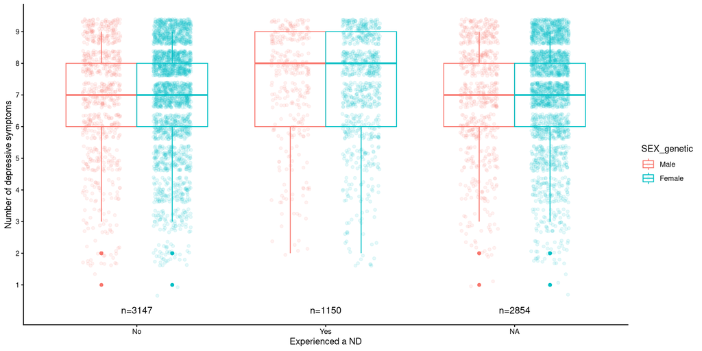

```r
ggplot(df_ND_covid[!is.na(df_ND_covid$SEX_genetic),], aes(x = as.factor(NDEXPOS_DEPRFAFTER), y = NUMSYMPALL_followup, colour = SEX_genetic)) +
  geom_boxplot(position = position_dodge(width = 0.75)) +
  geom_point(position = position_jitterdodge(dodge.width = 0.75, jitter.width = 0.4, jitter.height = 0.4), alpha = 0.1) +
  stat_n_text() +
  labs(x = "Experienced a ND",
       y = "Number of depressive symptoms") +
  scale_y_continuous(breaks = c(1,2,3,4,5,6,7,8,9)) +
  theme(axis.text.x = element_text(angle = 45, vjust = 1, hjust=1)) +
  theme_classic()
```

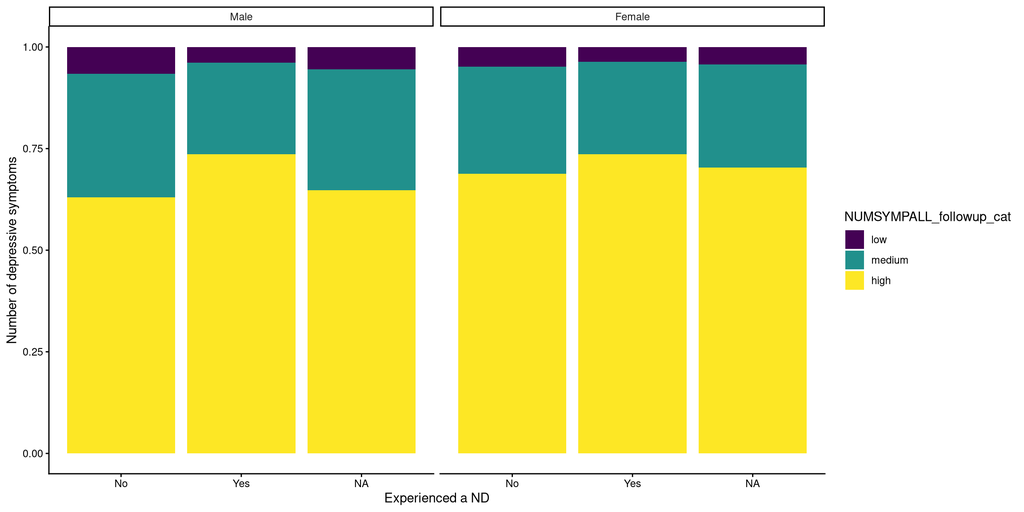

```r
ggplot(df_ND_covid[!is.na(df_ND_covid$SEX_genetic) & !is.na(df_ND_covid$NUMSYMPALL_followup_cat),], aes(x = as.factor(NDEXPOS_DEPRFAFTER), fill = NUMSYMPALL_followup_cat)) +
  geom_bar(position = "fill") +
  # stat_n_text() +
  labs(x = "Experienced a ND",
       y = "Number of depressive symptoms") +
  facet_wrap(~ SEX_genetic) +
  theme(axis.text.x = element_text(angle = 45, vjust = 1, hjust=1)) +
  theme_classic()
```

## Fit Models

### Proportional Odds

```r
NDFirst_PO <- VGAM::vglm(NUMSYMPALL_followup_cat ~
                                  PRS_stand_genetic +
                                  NDEXPOS_DEPRFAFTER +
                                  AGE_baseline +
                                  SEX_genetic +
                                  PC1_genetic +
                                  PC2_genetic +
                                  PC3_genetic +
                                  PC4_genetic +
                           PC5_genetic +
                           PC6_genetic +
                           PC7_genetic +
                           PC8_genetic +
                           PC9_genetic +
                           PC10_genetic,
                                family = VGAM::cumulative(logitlink, parallel = T, reverse = T), # with PO (package pammtools masks VGAM cumulative so specify from VGAM)
                                data = df_ND_covid)

NDFirst_female_PO <- VGAM::vglm(NUMSYMPALL_followup_cat ~
                                  PRS_stand_genetic +
                                  NDEXPOS_DEPRFAFTER +
                                  AGE_baseline +
                                  PC1_genetic +
                                  PC2_genetic +
                                  PC3_genetic +
                                  PC4_genetic +
                                  PC5_genetic +
                                  PC6_genetic +
                                  PC7_genetic +
                                  PC8_genetic +
                                  PC9_genetic +
                                  PC10_genetic,
                                family = VGAM::cumulative(logitlink, parallel = T, reverse = T), # with PO (package pammtools masks VGAM cumulative so specify from VGAM)
                                data = df_ND_covid[df_ND_covid$SEX_genetic == "Female", ])

NDFirst_male_PO <- VGAM::vglm(NUMSYMPALL_followup_cat ~
                                PRS_stand_genetic +
                                NDEXPOS_DEPRFAFTER +
                                AGE_baseline +
                                PC1_genetic +
                                PC2_genetic +
                                PC3_genetic +
                                PC4_genetic +
                                PC5_genetic +
                                PC6_genetic +
                                PC7_genetic +
                                PC8_genetic +
                                PC9_genetic +
                                PC10_genetic,
                              family = VGAM::cumulative(logitlink, parallel = T, reverse = T), # with PO (package pammtools masks VGAM cumulative so specify from VGAM)
                              data = df_ND_covid[df_ND_covid$SEX_genetic == "Male", ])
```

### Partial Proportional Odds

```r
NDFirst_PartPO_NDexpos <- VGAM::vglm(NUMSYMPALL_followup_cat ~
                                             PRS_stand_genetic +
                                             NDEXPOS_DEPRFAFTER +
                                             AGE_baseline +
                                             SEX_genetic +
                                             PC1_genetic +
                                             PC2_genetic +
                                             PC3_genetic +
                                             PC4_genetic +
                                       PC5_genetic +
                                       PC6_genetic +
                                       PC7_genetic +
                                       PC8_genetic +
                                       PC9_genetic +
                                       PC10_genetic,
                                           family = VGAM::cumulative(logitlink, parallel = F ~ NDEXPOS_DEPRFAFTER, reverse = T), # with PO (package pammtools masks VGAM cumulative so specify from VGAM)
                                           data = df_ND_covid)

NDFirst_PartPO_PRS <- VGAM::vglm(NUMSYMPALL_followup_cat ~
                                          PRS_stand_genetic +
                                          NDEXPOS_DEPRFAFTER +
                                          AGE_baseline +
                                          SEX_genetic +
                                          PC1_genetic +
                                          PC2_genetic +
                                          PC3_genetic +
                                          PC4_genetic +
                                   PC5_genetic +
                                   PC6_genetic +
                                   PC7_genetic +
                                   PC8_genetic +
                                   PC9_genetic +
                                   PC10_genetic,
                                        family = VGAM::cumulative(logitlink, parallel = F ~ PRS_stand_genetic, reverse = T), # with PO (package pammtools masks VGAM cumulative so specify from VGAM)
                                        data = df_ND_covid)

NDFirst_PartPO_NDexpos_PRS <- VGAM::vglm(NUMSYMPALL_followup_cat ~
                                                  PRS_stand_genetic +
                                                  NDEXPOS_DEPRFAFTER +
                                                  AGE_baseline +
                                                  SEX_genetic +
                                                  PC1_genetic +
                                                  PC2_genetic +
                                                  PC3_genetic +
                                                  PC4_genetic +
                                           PC5_genetic +
                                           PC6_genetic +
                                           PC7_genetic +
                                           PC8_genetic +
                                           PC9_genetic +
                                           PC10_genetic,
                                                family = VGAM::cumulative(logitlink, parallel = F ~ NDEXPOS_DEPRFAFTER + PRS_stand_genetic, reverse = T), # with PO (package pammtools masks VGAM cumulative so specify from VGAM)
                                                data = df_ND_covid)



NDFirst_female_PartPO_NDexpos <- VGAM::vglm(NUMSYMPALL_followup_cat ~
                                              PRS_stand_genetic +
                                              NDEXPOS_DEPRFAFTER +
                                              AGE_baseline +
                                              PC1_genetic +
                                              PC2_genetic +
                                              PC3_genetic +
                                              PC4_genetic +
                                              PC5_genetic +
                                              PC6_genetic +
                                              PC7_genetic +
                                              PC8_genetic +
                                              PC9_genetic +
                                              PC10_genetic,
                                            family = VGAM::cumulative(logitlink, parallel = F ~ NDEXPOS_DEPRFAFTER, reverse = T), # with PO (package pammtools masks VGAM cumulative so specify from VGAM)
                                            data = df_ND_covid[df_ND_covid$SEX_genetic == "Female", ])

NDFirst_female_PartPO_PRS <- VGAM::vglm(NUMSYMPALL_followup_cat ~
                                          PRS_stand_genetic +
                                          NDEXPOS_DEPRFAFTER +
                                          AGE_baseline +
                                          PC1_genetic +
                                          PC2_genetic +
                                          PC3_genetic +
                                          PC4_genetic +
                                          PC5_genetic +
                                          PC6_genetic +
                                          PC7_genetic +
                                          PC8_genetic +
                                          PC9_genetic +
                                          PC10_genetic,
                                        family = VGAM::cumulative(logitlink, parallel = F ~ PRS_stand_genetic, reverse = T), # with PO (package pammtools masks VGAM cumulative so specify from VGAM)
                                        data = df_ND_covid[df_ND_covid$SEX_genetic == "Female", ])

NDFirst_female_PartPO_NDexpos_PRS <- VGAM::vglm(NUMSYMPALL_followup_cat ~
                                                  PRS_stand_genetic +
                                                  NDEXPOS_DEPRFAFTER +
                                                  AGE_baseline +
                                                  PC1_genetic +
                                                  PC2_genetic +
                                                  PC3_genetic +
                                                  PC4_genetic +
                                                  PC5_genetic +
                                                  PC6_genetic +
                                                  PC7_genetic +
                                                  PC8_genetic +
                                                  PC9_genetic +
                                                  PC10_genetic,
                                                family = VGAM::cumulative(logitlink, parallel = F ~ NDEXPOS_DEPRFAFTER + PRS_stand_genetic, reverse = T), # with PO (package pammtools masks VGAM cumulative so specify from VGAM)
                                                data = df_ND_covid[df_ND_covid$SEX_genetic == "Female", ])

NDFirst_male_PartPO_NDexpos <- VGAM::vglm(NUMSYMPALL_followup_cat ~
                                            PRS_stand_genetic +
                                            NDEXPOS_DEPRFAFTER +
                                            AGE_baseline +
                                            PC1_genetic +
                                            PC2_genetic +
                                            PC3_genetic +
                                            PC4_genetic +
                                            PC5_genetic +
                                            PC6_genetic +
                                            PC7_genetic +
                                            PC8_genetic +
                                            PC9_genetic +
                                            PC10_genetic,
                                          family = VGAM::cumulative(logitlink, parallel = F ~ NDEXPOS_DEPRFAFTER, reverse = T), # with PO (package pammtools masks VGAM cumulative so specify from VGAM)
                                          data = df_ND_covid[df_ND_covid$SEX_genetic == "Male", ])

NDFirst_male_PartPO_PRS <- VGAM::vglm(NUMSYMPALL_followup_cat ~
                                        PRS_stand_genetic +
                                        NDEXPOS_DEPRFAFTER +
                                        AGE_baseline +
                                        PC1_genetic +
                                        PC2_genetic +
                                        PC3_genetic +
                                        PC4_genetic +
                                        PC5_genetic +
                                        PC6_genetic +
                                        PC7_genetic +
                                        PC8_genetic +
                                        PC9_genetic +
                                        PC10_genetic,
                                      family = VGAM::cumulative(logitlink, parallel = F ~ PRS_stand_genetic, reverse = T), # with PO (package pammtools masks VGAM cumulative so specify from VGAM)
                                      data = df_ND_covid[df_ND_covid$SEX_genetic == "Male", ])

NDFirst_male_PartPO_NDexpos_PRS <- VGAM::vglm(NUMSYMPALL_followup_cat ~
                                                PRS_stand_genetic +
                                                NDEXPOS_DEPRFAFTER +
                                                AGE_baseline +
                                                PC1_genetic +
                                                PC2_genetic +
                                                PC3_genetic +
                                                PC4_genetic +
                                                PC5_genetic +
                                                PC6_genetic +
                                                PC7_genetic +
                                                PC8_genetic +
                                                PC9_genetic +
                                                PC10_genetic,
                                              family = VGAM::cumulative(logitlink, parallel = F ~ NDEXPOS_DEPRFAFTER + PRS_stand_genetic, reverse = T), # with PO (package pammtools masks VGAM cumulative so specify from VGAM)
                                              data = df_ND_covid[df_ND_covid$SEX_genetic == "Male", ])
```

## Check Models

### Proportional Odds

#### Both sexes

```r
### Test goodness of fit ###

# lipsitz test
lipsitz(NDFirst_PO)
```

```
##
## Lipsitz Test:
##
##                       LR   df   pr(>chi)
## ordinal(lipsitz)  7.5408    9      0.581
##
## H0: No lack of fit dictated
```

```r
# pulkstenis-robinson test
# (requires the vector of categorical input variables as an argument)
pulkroben(NDFirst_PO, test = c("chisq","deviance"), tables = FALSE)
```

```
##
## Pulkstenis-Robinson Chi-squared Test:
##
##                     chi-sq   df   pr(>chi)
## ordinal(pulkroben)  12.685   11     0.3144
##
## H0: No lack of fit dictated
##
## rho: 100%
```

```r
# Hosmer-Lemeshow test
hosmerlem(NDFirst_PO)
```

```
##
## Hosmer-Lemeshow Test:
##
##                     Chi-sq  df  pr(>chi)
## ordinal(Hosmerlem)   11.75  17    0.8151
##
## H0: No lack of fit dictated
##
## rho: 100%
```

```r
### Test proportional odds assumption ###

# Brant Wald Test
# A generalized ordinal logistic regression model is approximated and compared to the calculated proportional odds model (a generalized ordinal logistic regression model is simply a relaxing of the proportional odds model to allow for different coefficients at each level of the ordinal outcome variable.)
# A Wald test is a hypothesis test of the significance of the difference in model coefficients, producing a chi-square statistic. A low p-value in a Brant-Wald test is an indicator that the coefficient does not satisfy the proportional odds assumption.
# A p-value of less than 0.05 on this test, particularly on the Omnibus plus at least one of the variables should be interpreted as a failure of the proportional odds assumption.

brant.test(NDFirst_PO)
```

```
##
## Brant Test:
##                          chi-sq   df   pr(>chi)
## Omnibus                  11.071   14      0.680
## PRS_stand_genetic         0.490    1      0.484
## NDEXPOS_DEPRFAFTERYes     0.455    1      0.500
## AGE_baseline              1.763    1      0.184
## SEX_geneticFemale         0.118    1      0.731
## PC1_genetic               0.491    1      0.483
## PC2_genetic               0.029    1      0.866
## PC3_genetic               0.386    1      0.534
## PC4_genetic               0.666    1      0.414
## PC5_genetic               0.112    1      0.738
## PC6_genetic               0.007    1      0.933
## PC7_genetic               3.489    1      0.062 .
## PC8_genetic               0.159    1      0.690
## PC9_genetic               0.701    1      0.403
## PC10_genetic              0.027    1      0.870
## ---
## Signif. codes:  0 '***' 0.001 '**' 0.01 '*' 0.05 '.' 0.1 ' ' 1
##
## H0: Proportional odds assumption holds
```

```r
# Sighting coefficients of stratified binomial models - want each to be similar
# create binary variables for every combo of the 3 categories
x <- df_ND_covid %>%
  mutate(SYMPlowplus = case_when(
    NUMSYMPALL_baseline_cat == 'low' ~ 0,
    NUMSYMPALL_baseline_cat == 'medium' |  NUMSYMPALL_baseline_cat == 'high' ~ 1),
    SYMPmedplus = case_when(
      NUMSYMPALL_baseline_cat == 'low' | NUMSYMPALL_baseline_cat == 'medium' ~ 0,
      NUMSYMPALL_baseline_cat == 'high' ~ 1)
  )


# Create logistic regression for each
lowplus_model <- glm(SYMPlowplus ~
                       PRS_stand_genetic +
                       NDEXPOS_DEPRFAFTER +
                       AGE_baseline +
                       SEX_genetic +
                       PC1_genetic +
                       PC2_genetic +
                       PC3_genetic +
                       PC4_genetic +
                       PC5_genetic +
                       PC6_genetic +
                       PC7_genetic +
                       PC8_genetic +
                       PC9_genetic +
                       PC10_genetic,
                     family = binomial(link = 'logit'),
                     data = x)

medplus_model <- glm(SYMPmedplus ~
                       PRS_stand_genetic +
                       NDEXPOS_DEPRFAFTER +
                       AGE_baseline +
                       SEX_genetic +
                       PC1_genetic +
                       PC2_genetic +
                       PC3_genetic +
                       PC4_genetic +
                       PC5_genetic +
                       PC6_genetic +
                       PC7_genetic +
                       PC8_genetic +
                       PC9_genetic +
                       PC10_genetic,
                     family = binomial(link = 'logit'),
                     data = x)


# display the coefficients of all models and examine the difference between them.
# coefficients (i.e. the slopes) should be similar for all models to hold the proportional odds assumption

# table
coeffs <- data.frame(
  'ordinal' = coef(NDFirst_PO)[-c(1,2)],
  'binary low vs med and high' = lowplus_model$coefficients[-1],
  'binary low and med vs high' = medplus_model$coefficients[-1])

coeffs %>%
  kable()
```

|  | ordinal | binary.low.vs.med.and.high | binary.low.and.med.vs.high |
| --- | --- | --- | --- |
| PRS_stand_genetic | 0.0295381 | 0.1893372 | 0.1452636 |
| NDEXPOS_DEPRFAFTERYes | 0.3218467 | 0.3647267 | 0.2932357 |
| AGE_baseline | -0.0124645 | -0.0611881 | -0.0333886 |
| SEX_geneticFemale | 0.0941813 | 1.2533945 | 0.4265546 |
| PC1_genetic | 158.9682462 | -430.0013097 | 72.0815975 |
| PC2_genetic | -18.0631447 | -68.5972772 | -61.2320249 |
| PC3_genetic | -15.8482535 | 24.4323518 | -11.4813738 |
| PC4_genetic | 4.9853988 | 79.6441812 | -1.6245643 |
| PC5_genetic | -2.3066700 | 116.2938922 | 9.1160345 |
| PC6_genetic | -7.9310904 | 51.2608974 | 0.0123698 |
| PC7_genetic | -10.3108799 | 14.2283550 | 13.6935723 |
| PC8_genetic | -0.9324477 | 4.2308454 | -18.5924657 |
| PC9_genetic | 2.1831249 | -32.5738081 | -11.7252287 |
| PC10_genetic | -0.7750654 | 51.1323068 | -9.4871639 |

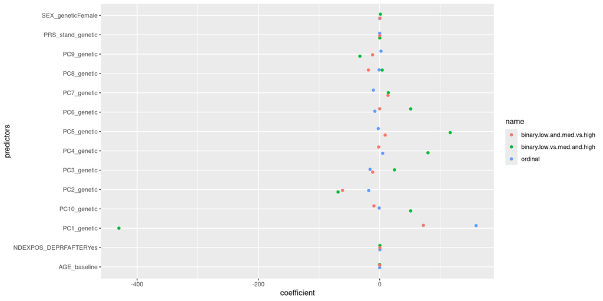

```r
coeffs2 <- coeffs %>%
  rownames_to_column() %>%
  pivot_longer(cols = 2:4)

ggplot(coeffs2, aes(x = value, y = rowname, group = name, colour = name)) +
  geom_jitter(height = 0.2) +
  labs(x = "coefficient", y = "predictors")
```

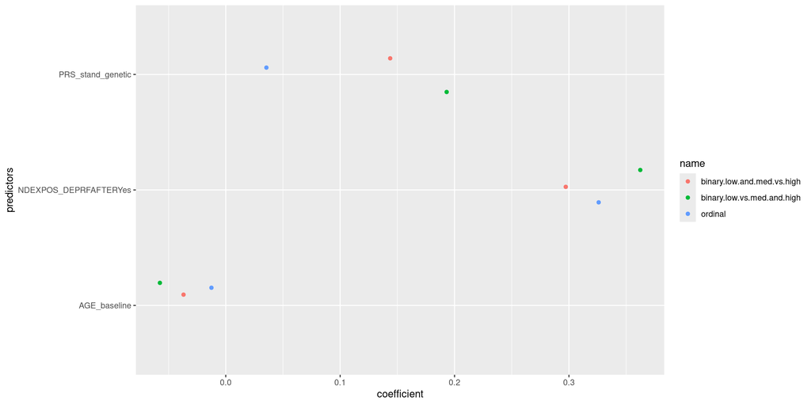

```r
coeffs3 <- coeffs2 %>%
  filter(rowname == 'PRS_stand_genetic' | rowname == 'NDEXPOS_DEPRFAFTERYes' | rowname == "AGE_baseline")

ggplot(coeffs3, aes(x = value, y = rowname, group = name, colour = name)) +
  geom_jitter(height = 0.2) +
  labs(x = "coefficient", y = "predictors")
```

- Goodness of fit OK
- Brant test shows proportional odds assumption OK
- Visual inspection shows PO may not hold for ND exposure and possibly not for PRS (and PCs)

#### Female

```r
### Test goodness of fit ###

# lipsitz test
lipsitz(NDFirst_female_PO)
```

```
##
## Lipsitz Test:
##
##                       LR   df   pr(>chi)
## ordinal(lipsitz)  5.5737    9     0.7817
##
## H0: No lack of fit dictated
```

```r
# pulkstenis-robinson test
# (requires the vector of categorical input variables as an argument)
pulkroben(NDFirst_female_PO, test = c("chisq","deviance"), tables = FALSE)
```

```
##
## Pulkstenis-Robinson Chi-squared Test:
##
##                     chi-sq   df   pr(>chi)
## ordinal(pulkroben)  4.0955    4     0.3932
##
## H0: No lack of fit dictated
##
## rho: 100%
```

```r
# Hosmer-Lemeshow test
hosmerlem(NDFirst_female_PO)
```

```
##
## Hosmer-Lemeshow Test:
##
##                     Chi-sq  df  pr(>chi)
## ordinal(Hosmerlem)  13.493  17    0.7026
##
## H0: No lack of fit dictated
##
## rho: 100%
```

```r
### Test proportional odds assumption ###

# Brant Wald Test
# A generalized ordinal logistic regression model is approximated and compared to the calculated proportional odds model (a generalized ordinal logistic regression model is simply a relaxing of the proportional odds model to allow for different coefficients at each level of the ordinal outcome variable.)
# A Wald test is a hypothesis test of the significance of the difference in model coefficients, producing a chi-square statistic. A low p-value in a Brant-Wald test is an indicator that the coefficient does not satisfy the proportional odds assumption.
# A p-value of less than 0.05 on this test, particularly on the Omnibus plus at least one of the variables should be interpreted as a failure of the proportional odds assumption.

brant.test(NDFirst_female_PO)
```

```
##
## Brant Test:
##                          chi-sq   df   pr(>chi)
## Omnibus                  15.927   13      0.253
## PRS_stand_genetic         0.157    1      0.692
## NDEXPOS_DEPRFAFTERYes     0.252    1      0.616
## AGE_baseline              2.090    1      0.148
## PC1_genetic               0.999    1      0.317
## PC2_genetic               0.181    1      0.671
## PC3_genetic               1.404    1      0.236
## PC4_genetic               1.524    1      0.217
## PC5_genetic               0.418    1      0.518
## PC6_genetic               0.381    1      0.537
## PC7_genetic               6.291    1      0.012 *
## PC8_genetic               0.171    1      0.680
## PC9_genetic               0.767    1      0.381
## PC10_genetic              0.071    1      0.790
## ---
## Signif. codes:  0 '***' 0.001 '**' 0.01 '*' 0.05 '.' 0.1 ' ' 1
##
## H0: Proportional odds assumption holds
```

```r
# Sighting coefficients of stratified binomial models - want each to be similar
# create binary variables for every combo of the 3 categories
x <- df_ND_covid %>%
  mutate(SYMPlowplus = case_when(
    NUMSYMPALL_baseline_cat == 'low' ~ 0,
    NUMSYMPALL_baseline_cat == 'medium' |  NUMSYMPALL_baseline_cat == 'high' ~ 1),
    SYMPmedplus = case_when(
      NUMSYMPALL_baseline_cat == 'low' | NUMSYMPALL_baseline_cat == 'medium' ~ 0,
      NUMSYMPALL_baseline_cat == 'high' ~ 1)
  )


# Create logistic regression for each
lowplus_model <- glm(SYMPlowplus ~
                       PRS_stand_genetic +
                       NDEXPOS_DEPRFAFTER +
                       AGE_baseline +
                       PC1_genetic +
                       PC2_genetic +
                       PC3_genetic +
                       PC4_genetic +
                       PC5_genetic +
                       PC6_genetic +
                       PC7_genetic +
                       PC8_genetic +
                       PC9_genetic +
                       PC10_genetic,
                     family = binomial(link = 'logit'),
                     data = x[x$SEX_genetic == "Female", ])

medplus_model <- glm(SYMPmedplus ~
                       PRS_stand_genetic +
                       NDEXPOS_DEPRFAFTER +
                       AGE_baseline +
                       PC1_genetic +
                       PC2_genetic +
                       PC3_genetic +
                       PC4_genetic +
                       PC5_genetic +
                       PC6_genetic +
                       PC7_genetic +
                       PC8_genetic +
                       PC9_genetic +
                       PC10_genetic,
                     family = binomial(link = 'logit'),
                     data = x[x$SEX_genetic == "Female", ])


# display the coefficients of all models and examine the difference between them.
# coefficients (i.e. the slopes) should be similar for all models to hold the proportional odds assumption

# table
coeffs <- data.frame(
  'ordinal' = coef(NDFirst_female_PO)[-c(1,2)],
  'binary low vs med and high' = lowplus_model$coefficients[-1],
  'binary low and med vs high' = medplus_model$coefficients[-1])

coeffs %>%
  kable()
```

|  | ordinal | binary.low.vs.med.and.high | binary.low.and.med.vs.high |
| --- | --- | --- | --- |
| PRS_stand_genetic | 0.0335562 | 0.3021395 | 0.0844500 |
| NDEXPOS_DEPRFAFTERYes | 0.2419555 | 0.5983277 | 0.2733978 |
| AGE_baseline | -0.0098481 | -0.0395381 | -0.0354150 |
| PC1_genetic | 165.0995102 | -637.5680671 | -45.4485963 |
| PC2_genetic | -7.5321697 | -809.0610461 | -12.7132137 |
| PC3_genetic | -9.6319712 | -124.0452275 | -36.9710549 |
| PC4_genetic | 3.2013347 | -216.4740114 | 21.6233523 |
| PC5_genetic | -5.6934886 | 186.7841688 | 3.9327395 |
| PC6_genetic | -5.2504836 | 55.8991766 | 2.7627899 |
| PC7_genetic | -17.2370269 | 137.2622629 | 22.9993103 |
| PC8_genetic | 3.3292973 | -113.3681883 | -23.5345973 |
| PC9_genetic | 0.6715383 | 19.1630037 | -18.2698883 |
| PC10_genetic | -2.3288935 | 123.4106584 | -3.9768057 |

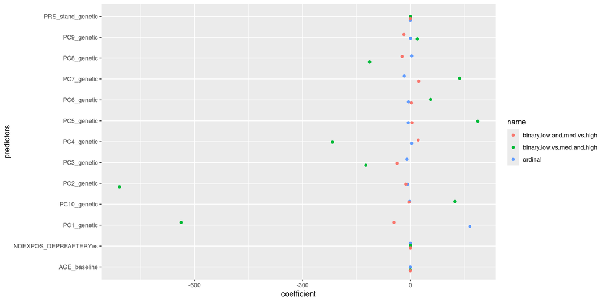

```r
coeffs2 <- coeffs %>%
  rownames_to_column() %>%
  pivot_longer(cols = 2:4)

ggplot(coeffs2, aes(x = value, y = rowname, group = name, colour = name)) +
  geom_jitter(height = 0.2) +
  labs(x = "coefficient", y = "predictors")
```

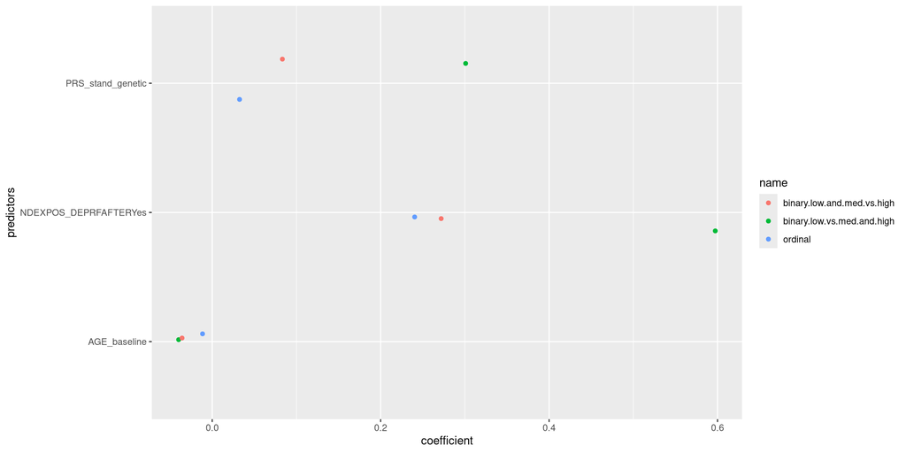

```r
coeffs3 <- coeffs2 %>%
  filter(rowname == 'PRS_stand_genetic' | rowname == 'NDEXPOS_DEPRFAFTERYes' | rowname == "AGE_baseline")

ggplot(coeffs3, aes(x = value, y = rowname, group = name, colour = name)) +
  geom_jitter(height = 0.2) +
  labs(x = "coefficient", y = "predictors")
```

- Goodness of fit OK
- Brant test shows proportional odds assumption OK
- Visual inspection shows PO may not hold for ND exposure and possibly not for PRS (and PCs)

#### Male

```r
### Test goodness of fit ###

# lipsitz test
lipsitz(NDFirst_male_PO)
```

```
##
## Lipsitz Test:
##
##                       LR   df   pr(>chi)
## ordinal(lipsitz)  9.7549    9     0.3707
##
## H0: No lack of fit dictated
```

```r
# pulkstenis-robinson test
# (requires the vector of categorical input variables as an argument)
pulkroben(NDFirst_male_PO, test = c("chisq","deviance"), tables = FALSE)
```

```
##
## Pulkstenis-Robinson Chi-squared Test:
##
##                     chi-sq   df   pr(>chi)
## ordinal(pulkroben)  3.6054    4      0.462
##
## H0: No lack of fit dictated
##
## rho: 100%
```

```r
# Hosmer-Lemeshow test
hosmerlem(NDFirst_male_PO)
```

```
##
## Hosmer-Lemeshow Test:
##
##                     Chi-sq  df  pr(>chi)
## ordinal(Hosmerlem)  21.806  17    0.1923
##
## H0: No lack of fit dictated
##
## rho: 100%
```

```r
### Test proportional odds assumption ###

# Brant Wald Test
# A generalized ordinal logistic regression model is approximated and compared to the calculated proportional odds model (a generalized ordinal logistic regression model is simply a relaxing of the proportional odds model to allow for different coefficients at each level of the ordinal outcome variable.)
# A Wald test is a hypothesis test of the significance of the difference in model coefficients, producing a chi-square statistic. A low p-value in a Brant-Wald test is an indicator that the coefficient does not satisfy the proportional odds assumption.
# A p-value of less than 0.05 on this test, particularly on the Omnibus plus at least one of the variables should be interpreted as a failure of the proportional odds assumption.

brant.test(NDFirst_male_PO)
```

```
##
## Brant Test:
##                          chi-sq   df   pr(>chi)
## Omnibus                   6.890   13      0.908
## PRS_stand_genetic         3.783    1      0.052 .
## NDEXPOS_DEPRFAFTERYes     0.076    1      0.783
## AGE_baseline              0.032    1      0.859
## PC1_genetic               0.364    1      0.546
## PC2_genetic               1.743    1      0.187
## PC3_genetic               0.457    1      0.499
## PC4_genetic               0.171    1      0.679
## PC5_genetic               0.104    1      0.747
## PC6_genetic               0.791    1      0.374
## PC7_genetic               0.243    1      0.622
## PC8_genetic               0.002    1      0.964
## PC9_genetic               0.003    1      0.955
## PC10_genetic              0.448    1      0.503
## ---
## Signif. codes:  0 '***' 0.001 '**' 0.01 '*' 0.05 '.' 0.1 ' ' 1
##
## H0: Proportional odds assumption holds
```

```r
# Sighting coefficients of stratified binomial models - want each to be similar
# create binary variables for every combo of the 3 categories
x <- df_ND_covid %>%
  mutate(SYMPlowplus = case_when(
    NUMSYMPALL_baseline_cat == 'low' ~ 0,
    NUMSYMPALL_baseline_cat == 'medium' |  NUMSYMPALL_baseline_cat == 'high' ~ 1),
    SYMPmedplus = case_when(
      NUMSYMPALL_baseline_cat == 'low' | NUMSYMPALL_baseline_cat == 'medium' ~ 0,
      NUMSYMPALL_baseline_cat == 'high' ~ 1)
  )


# Create logistic regression for each
lowplus_model <- glm(SYMPlowplus ~
                       PRS_stand_genetic +
                       NDEXPOS_DEPRFAFTER +
                       AGE_baseline +
                       PC1_genetic +
                       PC2_genetic +
                       PC3_genetic +
                       PC4_genetic +
                       PC5_genetic +
                       PC6_genetic +
                       PC7_genetic +
                       PC8_genetic +
                       PC9_genetic +
                       PC10_genetic,
                     family = binomial(link = 'logit'),
                     data = x[x$SEX_genetic == "Male", ])

medplus_model <- glm(SYMPmedplus ~
                       PRS_stand_genetic +
                       NDEXPOS_DEPRFAFTER +
                       AGE_baseline +
                       PC1_genetic +
                       PC2_genetic +
                       PC3_genetic +
                       PC4_genetic +
                       PC5_genetic +
                       PC6_genetic +
                       PC7_genetic +
                       PC8_genetic +
                       PC9_genetic +
                       PC10_genetic,
                     family = binomial(link = 'logit'),
                     data = x[x$SEX_genetic == "Male", ])


# display the coefficients of all models and examine the difference between them.
# coefficients (i.e. the slopes) should be similar for all models to hold the proportional odds assumption

# table
coeffs <- data.frame(
  'ordinal' = coef(NDFirst_male_PO)[-c(1,2)],
  'binary low vs med and high' = lowplus_model$coefficients[-1],
  'binary low and med vs high' = medplus_model$coefficients[-1])

coeffs %>%
  kable()
```

|  | ordinal | binary.low.vs.med.and.high | binary.low.and.med.vs.high |
| --- | --- | --- | --- |
| PRS_stand_genetic | 0.0180167 | 0.1041133 | 0.2494719 |
| NDEXPOS_DEPRFAFTERYes | 0.5298583 | 0.2754658 | 0.3196187 |
| AGE_baseline | -0.0203326 | -0.0832460 | -0.0295075 |
| PC1_genetic | 155.5187060 | -236.1851744 | 313.1775118 |
| PC2_genetic | -74.1748519 | 169.0404538 | -209.3770298 |
| PC3_genetic | -51.0158760 | 98.4893137 | 38.0516522 |
| PC4_genetic | 18.1956359 | 280.7266757 | -40.7904343 |
| PC5_genetic | 9.9311709 | 66.9868939 | 20.8187834 |
| PC6_genetic | -17.7979966 | 49.6508118 | -4.0736568 |
| PC7_genetic | 11.3427443 | -81.9551217 | -1.7619658 |
| PC8_genetic | -9.0589419 | 77.4413603 | -10.2942135 |
| PC9_genetic | 9.4413756 | -81.9008397 | -0.0078744 |
| PC10_genetic | 5.6887246 | 10.9149047 | -20.2915166 |

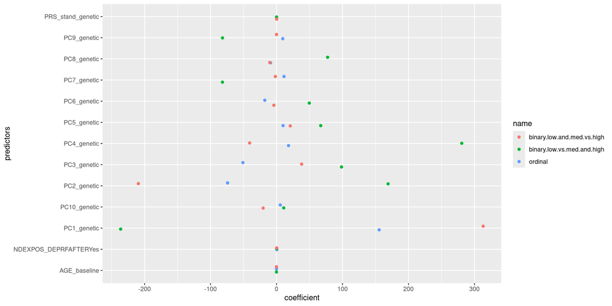

```r
coeffs2 <- coeffs %>%
  rownames_to_column() %>%
  pivot_longer(cols = 2:4)

ggplot(coeffs2, aes(x = value, y = rowname, group = name, colour = name)) +
  geom_jitter(height = 0.2) +
  labs(x = "coefficient", y = "predictors")
```

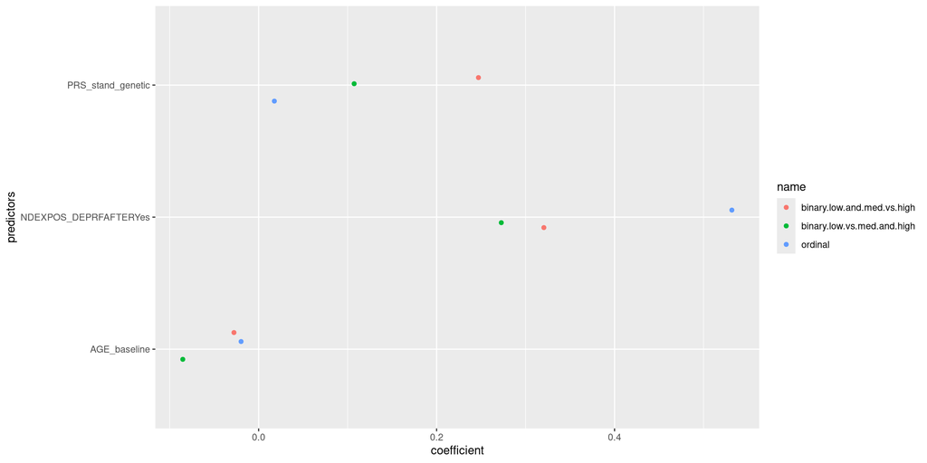

```r
coeffs3 <- coeffs2 %>%
  filter(rowname == 'PRS_stand_genetic' | rowname == 'NDEXPOS_DEPRFAFTERYes' | rowname == "AGE_baseline")

ggplot(coeffs3, aes(x = value, y = rowname, group = name, colour = name)) +
  geom_jitter(height = 0.2) +
  labs(x = "coefficient", y = "predictors")
```

- Goodness of fit OK
- Brant test shows proportional odds assumption OK
- Visual inspection shows PO may not hold for ND exposure and possibly not for PRS (and PCs)

### Partial Proportional Odds

#### Both Sexes

```r
# LRT to compare partial PO to PO models
lrtest(NDFirst_PO, NDFirst_PartPO_NDexpos)
```

```
## Likelihood ratio test
##
## Model 1: NUMSYMPALL_followup_cat ~ PRS_stand_genetic + NDEXPOS_DEPRFAFTER +
##     AGE_baseline + SEX_genetic + PC1_genetic + PC2_genetic +
##     PC3_genetic + PC4_genetic + PC5_genetic + PC6_genetic + PC7_genetic +
##     PC8_genetic + PC9_genetic + PC10_genetic
## Model 2: NUMSYMPALL_followup_cat ~ PRS_stand_genetic + NDEXPOS_DEPRFAFTER +
##     AGE_baseline + SEX_genetic + PC1_genetic + PC2_genetic +
##     PC3_genetic + PC4_genetic + PC5_genetic + PC6_genetic + PC7_genetic +
##     PC8_genetic + PC9_genetic + PC10_genetic
##    #Df  LogLik Df  Chisq Pr(>Chisq)
## 1 8578 -3201.0
## 2 8577 -3200.8 -1 0.2728     0.6014
```

```r
lrtest(NDFirst_PO, NDFirst_PartPO_PRS)
```

```
## Likelihood ratio test
##
## Model 1: NUMSYMPALL_followup_cat ~ PRS_stand_genetic + NDEXPOS_DEPRFAFTER +
##     AGE_baseline + SEX_genetic + PC1_genetic + PC2_genetic +
##     PC3_genetic + PC4_genetic + PC5_genetic + PC6_genetic + PC7_genetic +
##     PC8_genetic + PC9_genetic + PC10_genetic
## Model 2: NUMSYMPALL_followup_cat ~ PRS_stand_genetic + NDEXPOS_DEPRFAFTER +
##     AGE_baseline + SEX_genetic + PC1_genetic + PC2_genetic +
##     PC3_genetic + PC4_genetic + PC5_genetic + PC6_genetic + PC7_genetic +
##     PC8_genetic + PC9_genetic + PC10_genetic
##    #Df  LogLik Df  Chisq Pr(>Chisq)
## 1 8578 -3201.0
## 2 8577 -3200.7 -1 0.4828     0.4871
```

```r
lrtest(NDFirst_PO, NDFirst_PartPO_NDexpos_PRS)
```

```
## Likelihood ratio test
##
## Model 1: NUMSYMPALL_followup_cat ~ PRS_stand_genetic + NDEXPOS_DEPRFAFTER +
##     AGE_baseline + SEX_genetic + PC1_genetic + PC2_genetic +
##     PC3_genetic + PC4_genetic + PC5_genetic + PC6_genetic + PC7_genetic +
##     PC8_genetic + PC9_genetic + PC10_genetic
## Model 2: NUMSYMPALL_followup_cat ~ PRS_stand_genetic + NDEXPOS_DEPRFAFTER +
##     AGE_baseline + SEX_genetic + PC1_genetic + PC2_genetic +
##     PC3_genetic + PC4_genetic + PC5_genetic + PC6_genetic + PC7_genetic +
##     PC8_genetic + PC9_genetic + PC10_genetic
##    #Df  LogLik Df  Chisq Pr(>Chisq)
## 1 8578 -3201.0
## 2 8576 -3200.6 -2 0.7607     0.6836
```

```r
### Test goodness of fit ###

# lipsitz test
lipsitz(NDFirst_PartPO_NDexpos)
```

```
##
## Lipsitz Test:
##
##                       LR   df   pr(>chi)
## ordinal(lipsitz)  8.0305    9     0.5311
##
## H0: No lack of fit dictated
```

```r
lipsitz(NDFirst_PartPO_PRS)
```

```
##
## Lipsitz Test:
##
##                       LR   df   pr(>chi)
## ordinal(lipsitz)  7.1994    9     0.6164
##
## H0: No lack of fit dictated
```

```r
lipsitz(NDFirst_PartPO_NDexpos_PRS)
```

```
##
## Lipsitz Test:
##
##                       LR   df   pr(>chi)
## ordinal(lipsitz)  9.9975    9     0.3507
##
## H0: No lack of fit dictated
```

```r
# pulkstenis-robinson test
# (requires the vector of categorical input variables as an argument)
pulkroben(NDFirst_PartPO_NDexpos, test = c("chisq","deviance"), tables = FALSE)
```

```
##
## Pulkstenis-Robinson Chi-squared Test:
##
##                     chi-sq   df   pr(>chi)
## ordinal(pulkroben)  12.544   11     0.3242
##
## H0: No lack of fit dictated
##
## rho: 100%
```

```r
pulkroben(NDFirst_PartPO_PRS, test = c("chisq","deviance"), tables = FALSE)
```

```
##
## Pulkstenis-Robinson Chi-squared Test:
##
##                     chi-sq   df   pr(>chi)
## ordinal(pulkroben)  10.657   11     0.4724
##
## H0: No lack of fit dictated
##
## rho: 100%
```

```r
pulkroben(NDFirst_PartPO_NDexpos_PRS, test = c("chisq","deviance"), tables = FALSE)
```

```
##
## Pulkstenis-Robinson Chi-squared Test:
##
##                     chi-sq   df   pr(>chi)
## ordinal(pulkroben)  10.417   11     0.4933
##
## H0: No lack of fit dictated
##
## rho: 100%
```

```r
# Hosmer-Lemeshow test
hosmerlem(NDFirst_PartPO_NDexpos)
```

```
##
## Hosmer-Lemeshow Test:
##
##                     Chi-sq  df  pr(>chi)
## ordinal(Hosmerlem)  11.343  17    0.8382
##
## H0: No lack of fit dictated
##
## rho: 100%
```

```r
hosmerlem(NDFirst_PartPO_PRS)
```

```
##
## Hosmer-Lemeshow Test:
##
##                     Chi-sq  df  pr(>chi)
## ordinal(Hosmerlem)  11.694  17    0.8183
##
## H0: No lack of fit dictated
##
## rho: 100%
```

```r
hosmerlem(NDFirst_PartPO_PRS)
```

```
##
## Hosmer-Lemeshow Test:
##
##                     Chi-sq  df  pr(>chi)
## ordinal(Hosmerlem)  11.694  17    0.8183
##
## H0: No lack of fit dictated
##
## rho: 100%
```

- Relaxing PO assumption for ND exposure and/or PRS does not significantly improve model
- So best to use PO model

#### Female

```r
# LRT to compare partial PO to PO models
lrtest(NDFirst_female_PO, NDFirst_female_PartPO_NDexpos)
```

```
## Likelihood ratio test
##
## Model 1: NUMSYMPALL_followup_cat ~ PRS_stand_genetic + NDEXPOS_DEPRFAFTER +
##     AGE_baseline + PC1_genetic + PC2_genetic + PC3_genetic +
##     PC4_genetic + PC5_genetic + PC6_genetic + PC7_genetic + PC8_genetic +
##     PC9_genetic + PC10_genetic
## Model 2: NUMSYMPALL_followup_cat ~ PRS_stand_genetic + NDEXPOS_DEPRFAFTER +
##     AGE_baseline + PC1_genetic + PC2_genetic + PC3_genetic +
##     PC4_genetic + PC5_genetic + PC6_genetic + PC7_genetic + PC8_genetic +
##     PC9_genetic + PC10_genetic
##    #Df  LogLik Df  Chisq Pr(>Chisq)
## 1 6473 -2377.7
## 2 6472 -2377.6 -1 0.1909     0.6622
```

```r
lrtest(NDFirst_female_PO, NDFirst_female_PartPO_PRS)
```

```
## Likelihood ratio test
##
## Model 1: NUMSYMPALL_followup_cat ~ PRS_stand_genetic + NDEXPOS_DEPRFAFTER +
##     AGE_baseline + PC1_genetic + PC2_genetic + PC3_genetic +
##     PC4_genetic + PC5_genetic + PC6_genetic + PC7_genetic + PC8_genetic +
##     PC9_genetic + PC10_genetic
## Model 2: NUMSYMPALL_followup_cat ~ PRS_stand_genetic + NDEXPOS_DEPRFAFTER +
##     AGE_baseline + PC1_genetic + PC2_genetic + PC3_genetic +
##     PC4_genetic + PC5_genetic + PC6_genetic + PC7_genetic + PC8_genetic +
##     PC9_genetic + PC10_genetic
##    #Df  LogLik Df Chisq Pr(>Chisq)
## 1 6473 -2377.7
## 2 6472 -2377.6 -1 0.181     0.6705
```

```r
lrtest(NDFirst_female_PO, NDFirst_female_PartPO_NDexpos_PRS)
```

```
## Likelihood ratio test
##
## Model 1: NUMSYMPALL_followup_cat ~ PRS_stand_genetic + NDEXPOS_DEPRFAFTER +
##     AGE_baseline + PC1_genetic + PC2_genetic + PC3_genetic +
##     PC4_genetic + PC5_genetic + PC6_genetic + PC7_genetic + PC8_genetic +
##     PC9_genetic + PC10_genetic
## Model 2: NUMSYMPALL_followup_cat ~ PRS_stand_genetic + NDEXPOS_DEPRFAFTER +
##     AGE_baseline + PC1_genetic + PC2_genetic + PC3_genetic +
##     PC4_genetic + PC5_genetic + PC6_genetic + PC7_genetic + PC8_genetic +
##     PC9_genetic + PC10_genetic
##    #Df  LogLik Df  Chisq Pr(>Chisq)
## 1 6473 -2377.7
## 2 6471 -2377.5 -2 0.3714     0.8305
```

```r
### Test goodness of fit ###

# lipsitz test
lipsitz(NDFirst_female_PartPO_NDexpos)
```

```
##
## Lipsitz Test:
##
##                       LR   df   pr(>chi)
## ordinal(lipsitz)  5.1382    9     0.8221
##
## H0: No lack of fit dictated
```

```r
lipsitz(NDFirst_female_PartPO_PRS)
```

```
##
## Lipsitz Test:
##
##                       LR   df   pr(>chi)
## ordinal(lipsitz)  7.5694    9     0.5781
##
## H0: No lack of fit dictated
```

```r
lipsitz(NDFirst_female_PartPO_NDexpos_PRS)
```

```
##
## Lipsitz Test:
##
##                       LR   df   pr(>chi)
## ordinal(lipsitz)  7.4504    9     0.5903
##
## H0: No lack of fit dictated
```

```r
# pulkstenis-robinson test
# (requires the vector of categorical input variables as an argument)
pulkroben(NDFirst_female_PartPO_NDexpos, test = c("chisq","deviance"), tables = FALSE)
```

```
##
## Pulkstenis-Robinson Chi-squared Test:
##
##                     chi-sq   df   pr(>chi)
## ordinal(pulkroben)  3.9655    4     0.4107
##
## H0: No lack of fit dictated
##
## rho: 100%
```

```r
pulkroben(NDFirst_female_PartPO_PRS, test = c("chisq","deviance"), tables = FALSE)
```

```
##
## Pulkstenis-Robinson Chi-squared Test:
##
##                     chi-sq   df   pr(>chi)
## ordinal(pulkroben)  3.9111    4     0.4182
##
## H0: No lack of fit dictated
##
## rho: 100%
```

```r
pulkroben(NDFirst_female_PartPO_NDexpos_PRS, test = c("chisq","deviance"), tables = FALSE)
```

```
##
## Pulkstenis-Robinson Chi-squared Test:
##
##                     chi-sq   df   pr(>chi)
## ordinal(pulkroben)  3.5842    4     0.4652
##
## H0: No lack of fit dictated
##
## rho: 100%
```

```r
# Hosmer-Lemeshow test
hosmerlem(NDFirst_female_PartPO_NDexpos)
```

```
##
## Hosmer-Lemeshow Test:
##
##                     Chi-sq  df  pr(>chi)
## ordinal(Hosmerlem)      11  17    0.8566
##
## H0: No lack of fit dictated
##
## rho: 100%
```

```r
hosmerlem(NDFirst_female_PartPO_PRS)
```

```
##
## Hosmer-Lemeshow Test:
##
##                     Chi-sq  df  pr(>chi)
## ordinal(Hosmerlem)  15.049  17    0.5919
##
## H0: No lack of fit dictated
##
## rho: 100%
```

```r
hosmerlem(NDFirst_female_PartPO_PRS)
```

```
##
## Hosmer-Lemeshow Test:
##
##                     Chi-sq  df  pr(>chi)
## ordinal(Hosmerlem)  15.049  17    0.5919
##
## H0: No lack of fit dictated
##
## rho: 100%
```

- Relaxing PO assumption for ND exposure and/or PRS does not significantly improve model
- So best to use PO model

#### Male

```r
# LRT to compare partial PO to PO models
lrtest(NDFirst_male_PO, NDFirst_male_PartPO_NDexpos)
```

```
## Likelihood ratio test
##
## Model 1: NUMSYMPALL_followup_cat ~ PRS_stand_genetic + NDEXPOS_DEPRFAFTER +
##     AGE_baseline + PC1_genetic + PC2_genetic + PC3_genetic +
##     PC4_genetic + PC5_genetic + PC6_genetic + PC7_genetic + PC8_genetic +
##     PC9_genetic + PC10_genetic
## Model 2: NUMSYMPALL_followup_cat ~ PRS_stand_genetic + NDEXPOS_DEPRFAFTER +
##     AGE_baseline + PC1_genetic + PC2_genetic + PC3_genetic +
##     PC4_genetic + PC5_genetic + PC6_genetic + PC7_genetic + PC8_genetic +
##     PC9_genetic + PC10_genetic
##    #Df  LogLik Df  Chisq Pr(>Chisq)
## 1 2091 -817.62
## 2 2090 -817.59 -1 0.0508     0.8217
```

```r
lrtest(NDFirst_male_PO, NDFirst_male_PartPO_PRS)
```

```
## Likelihood ratio test
##
## Model 1: NUMSYMPALL_followup_cat ~ PRS_stand_genetic + NDEXPOS_DEPRFAFTER +
##     AGE_baseline + PC1_genetic + PC2_genetic + PC3_genetic +
##     PC4_genetic + PC5_genetic + PC6_genetic + PC7_genetic + PC8_genetic +
##     PC9_genetic + PC10_genetic
## Model 2: NUMSYMPALL_followup_cat ~ PRS_stand_genetic + NDEXPOS_DEPRFAFTER +
##     AGE_baseline + PC1_genetic + PC2_genetic + PC3_genetic +
##     PC4_genetic + PC5_genetic + PC6_genetic + PC7_genetic + PC8_genetic +
##     PC9_genetic + PC10_genetic
##    #Df  LogLik Df  Chisq Pr(>Chisq)
## 1 2091 -817.62
## 2 2090 -815.81 -1 3.6146    0.05728 .
## ---
## Signif. codes:  0 '***' 0.001 '**' 0.01 '*' 0.05 '.' 0.1 ' ' 1
```

```r
lrtest(NDFirst_male_PO, NDFirst_male_PartPO_NDexpos_PRS)
```

```
## Likelihood ratio test
##
## Model 1: NUMSYMPALL_followup_cat ~ PRS_stand_genetic + NDEXPOS_DEPRFAFTER +
##     AGE_baseline + PC1_genetic + PC2_genetic + PC3_genetic +
##     PC4_genetic + PC5_genetic + PC6_genetic + PC7_genetic + PC8_genetic +
##     PC9_genetic + PC10_genetic
## Model 2: NUMSYMPALL_followup_cat ~ PRS_stand_genetic + NDEXPOS_DEPRFAFTER +
##     AGE_baseline + PC1_genetic + PC2_genetic + PC3_genetic +
##     PC4_genetic + PC5_genetic + PC6_genetic + PC7_genetic + PC8_genetic +
##     PC9_genetic + PC10_genetic
##    #Df  LogLik Df  Chisq Pr(>Chisq)
## 1 2091 -817.62
## 2 2089 -815.76 -2 3.7047     0.1569
```

```r
### Test goodness of fit ###

# lipsitz test
lipsitz(NDFirst_male_PartPO_NDexpos)
```

```
##
## Lipsitz Test:
##
##                       LR   df   pr(>chi)
## ordinal(lipsitz)  8.7038    9     0.4651
##
## H0: No lack of fit dictated
```

```r
lipsitz(NDFirst_male_PartPO_PRS)
```

```
##
## Lipsitz Test:
##
##                       LR   df   pr(>chi)
## ordinal(lipsitz)  9.2589    9     0.4137
##
## H0: No lack of fit dictated
```

```r
lipsitz(NDFirst_male_PartPO_NDexpos_PRS)
```

```
##
## Lipsitz Test:
##
##                       LR   df   pr(>chi)
## ordinal(lipsitz)  8.8147    9     0.4545
##
## H0: No lack of fit dictated
```

```r
# pulkstenis-robinson test
# (requires the vector of categorical input variables as an argument)
pulkroben(NDFirst_male_PartPO_NDexpos, test = c("chisq","deviance"), tables = FALSE)
```

```
##
## Pulkstenis-Robinson Chi-squared Test:
##
##                     chi-sq   df   pr(>chi)
## ordinal(pulkroben)  3.6326    4      0.458
##
## H0: No lack of fit dictated
##
## rho: 100%
```

```r
pulkroben(NDFirst_male_PartPO_PRS, test = c("chisq","deviance"), tables = FALSE)
```

```
##
## Pulkstenis-Robinson Chi-squared Test:
##
##                     chi-sq   df   pr(>chi)
## ordinal(pulkroben)  4.2136    4     0.3779
##
## H0: No lack of fit dictated
##
## rho: 100%
```

```r
pulkroben(NDFirst_male_PartPO_NDexpos_PRS, test = c("chisq","deviance"), tables = FALSE)
```

```
##
## Pulkstenis-Robinson Chi-squared Test:
##
##                     chi-sq   df   pr(>chi)
## ordinal(pulkroben)  4.2366    4     0.3749
##
## H0: No lack of fit dictated
##
## rho: 100%
```

```r
# Hosmer-Lemeshow test
hosmerlem(NDFirst_male_PartPO_NDexpos)
```

```
##
## Hosmer-Lemeshow Test:
##
##                     Chi-sq  df  pr(>chi)
## ordinal(Hosmerlem)  20.608  17    0.2443
##
## H0: No lack of fit dictated
##
## rho: 100%
```

```r
hosmerlem(NDFirst_male_PartPO_PRS)
```

```
##
## Hosmer-Lemeshow Test:
##
##                     Chi-sq  df  pr(>chi)
## ordinal(Hosmerlem)  23.693  17     0.128
##
## H0: No lack of fit dictated
##
## rho: 100%
```

```r
hosmerlem(NDFirst_male_PartPO_PRS)
```

```
##
## Hosmer-Lemeshow Test:
##
##                     Chi-sq  df  pr(>chi)
## ordinal(Hosmerlem)  23.693  17     0.128
##
## H0: No lack of fit dictated
##
## rho: 100%
```

- Relaxing PO assumption for ND exposure and/or PRS does not significantly improve model
- So best to use PO model